# 6372: Project 1

Megan Ball, Matt Farrow, Neddy Nyatome

## Introduction

Using the World Health Organization (WHO) data compiled by Kumar Rajarshi, Deeksha Russell, and Duan Wang, we attempted to predict which factors affect life expectancy.

## Data Description

Description and context of the Life Expectancy (WHO) dataset can be found [here](https://www.kaggle.com/kumarajarshi/life-expectancy-who). Data has been compiled from several different data sets into a final data set that represents health factors for 193 countries between the years of 2000-2015.

```
## Rows: 2,938
## Columns: 22
## $ country                         <chr> "Afghanistan", "Afghanistan", "Afghan…
## $ year                            <dbl> 2015, 2014, 2013, 2012, 2011, 2010, 2…
## $ status                          <chr> "Developing", "Developing", "Developi…
## $ life_expectancy                 <dbl> 65.0, 59.9, 59.9, 59.5, 59.2, 58.8, 5…
## $ adult_mortality                 <dbl> 263, 271, 268, 272, 275, 279, 281, 28…
## $ infant_deaths                   <dbl> 62, 64, 66, 69, 71, 74, 77, 80, 82, 8…
## $ alcohol                         <dbl> 0.01, 0.01, 0.01, 0.01, 0.01, 0.01, 0…
## $ percentage_expenditure          <dbl> 71.279624, 73.523582, 73.219243, 78.1…
## $ hepatitis_b                     <dbl> 65, 62, 64, 67, 68, 66, 63, 64, 63, 6…
## $ measles                         <dbl> 1154, 492, 430, 2787, 3013, 1989, 286…
## $ bmi                             <dbl> 19.1, 18.6, 18.1, 17.6, 17.2, 16.7, 1…
## $ under_five_deaths               <dbl> 83, 86, 89, 93, 97, 102, 106, 110, 11…
## $ polio                           <dbl> 6, 58, 62, 67, 68, 66, 63, 64, 63, 58…
## $ total_expenditure               <dbl> 8.16, 8.18, 8.13, 8.52, 7.87, 9.20, 9…
## $ diphtheria                      <dbl> 65, 62, 64, 67, 68, 66, 63, 64, 63, 5…
## $ hiv_aids                        <dbl> 0.1, 0.1, 0.1, 0.1, 0.1, 0.1, 0.1, 0.…
## $ gdp                             <dbl> 584.25921, 612.69651, 631.74498, 669.…
## $ population                      <dbl> 33736494, 327582, 31731688, 3696958, …
## $ thinness_1_19_years             <dbl> 17.2, 17.5, 17.7, 17.9, 18.2, 18.4, 1…
## $ thinness_5_9_years              <dbl> 17.3, 17.5, 17.7, 18.0, 18.2, 18.4, 1…
## $ income_composition_of_resources <dbl> 0.479, 0.476, 0.470, 0.463, 0.454, 0.…
## $ schooling                       <dbl> 10.1, 10.0, 9.9, 9.8, 9.5, 9.2, 8.9, …
```

Looking at the data, there are 2,938 observatrions and 22 variables that cover various social, economic, and health-related factors.

## Exploratory Data Analysis

We’ll start by taking a closer look at life expectancy.

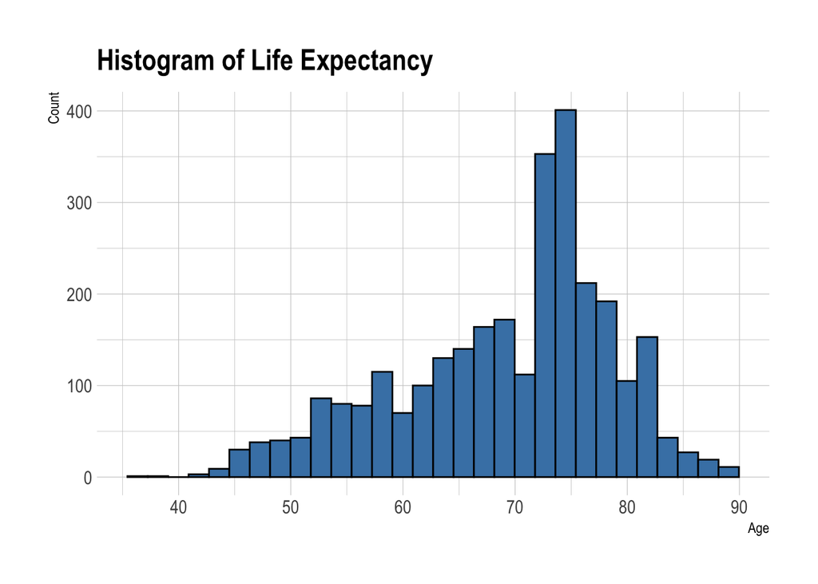

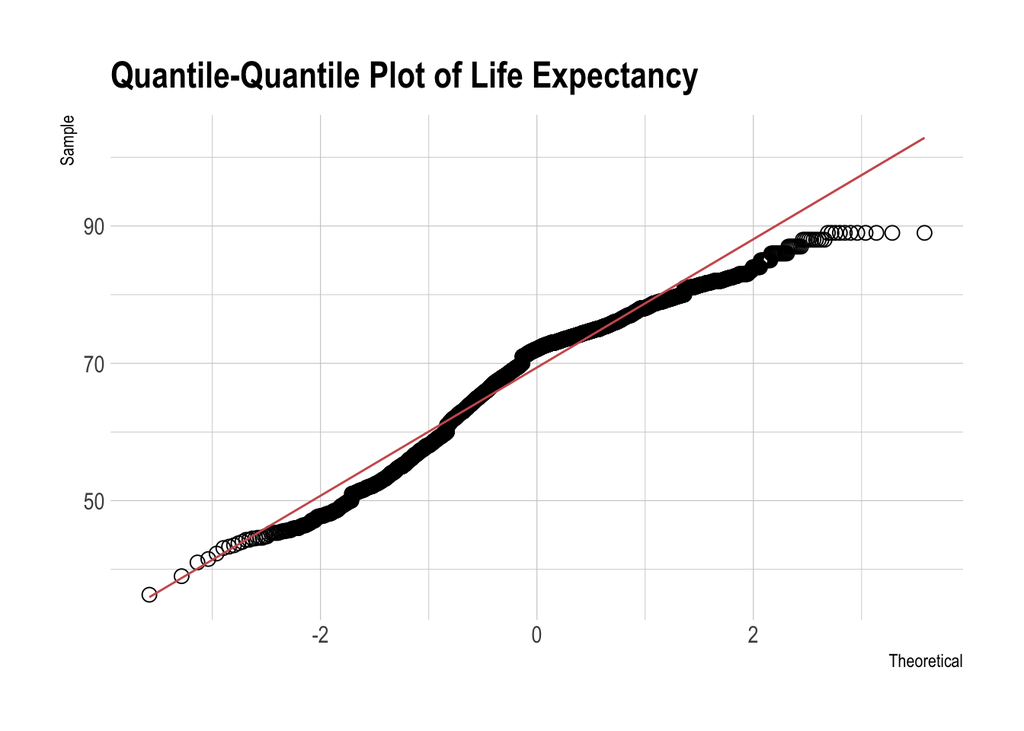

### Check for Correlation

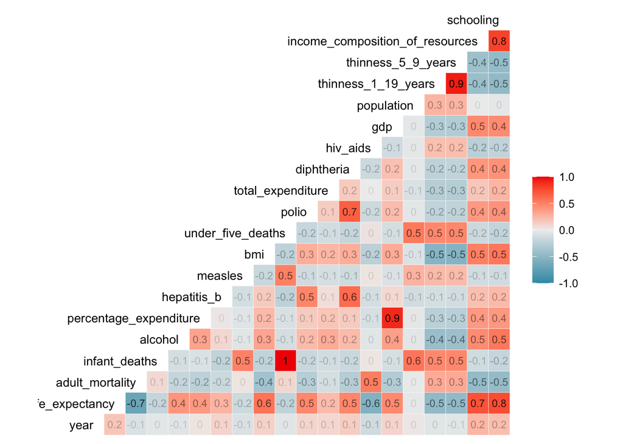

We examined various correlation matrices to determine whether there were variable(s) that should be addressed. We’ll start by removing redundant variables and picking ones with fewer `NA` values.

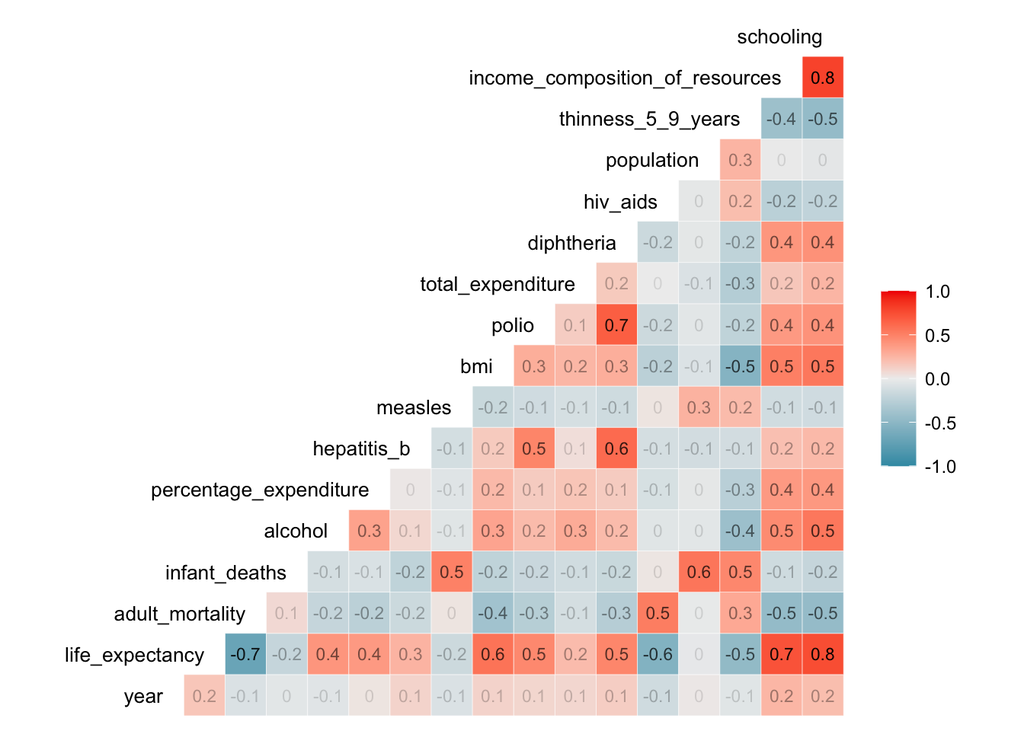

Let’s now look at what happens when we also remove `population`, since it has minimal correlation to `life_expectancy`.

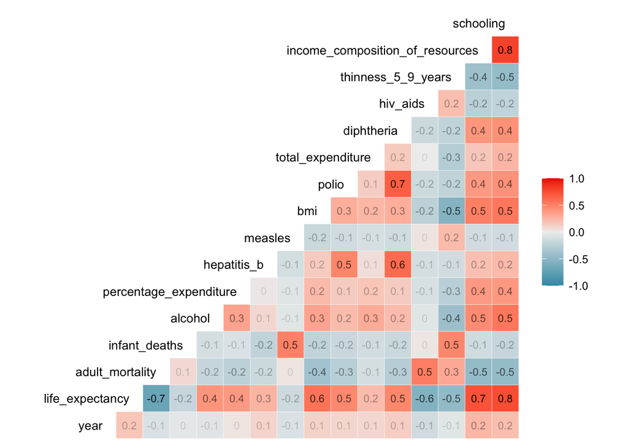

We’ll proceed, dropping the columns we’ve looked at.

### Deal with Missing Values

Check for missing values.

| variable | missing |
| --- | --- |
| country | 0 |
| year | 0 |
| status | 0 |
| life_expectancy | 10 |
| adult_mortality | 10 |
| infant_deaths | 0 |
| alcohol | 194 |
| percentage_expenditure | 0 |
| hepatitis_b | 553 |
| measles | 0 |
| bmi | 34 |
| polio | 19 |
| total_expenditure | 226 |
| diphtheria | 19 |
| hiv_aids | 0 |
| thinness_5_9_years | 34 |
| income_composition_of_resources | 167 |
| schooling | 163 |

Drop all rows where life expectancy is `NA`

```r
# Drop all rows where life expectancy is NA
df_clean <- df_clean %>%
  filter(!is.na(life_expectancy))

# Recheck missing value counts
tibble(variable = names(colSums(is.na(df_clean))),
       missing = colSums(is.na(df_clean))) %>%
  gt()
```

| variable | missing |
| --- | --- |
| country | 0 |
| year | 0 |
| status | 0 |
| life_expectancy | 0 |
| adult_mortality | 0 |
| infant_deaths | 0 |
| alcohol | 193 |
| percentage_expenditure | 0 |
| hepatitis_b | 553 |
| measles | 0 |
| bmi | 32 |
| polio | 19 |
| total_expenditure | 226 |
| diphtheria | 19 |
| hiv_aids | 0 |
| thinness_5_9_years | 32 |
| income_composition_of_resources | 160 |
| schooling | 160 |

Drop remaining rows with NA’s for the interpretable model

```r
# Drop remaining rows with NA's for the interpretable model
# Remove all rows with an NA
df_interp <- na.omit(df_clean)

# Final check of missing values
tibble(variable = names(colSums(is.na(df_interp))),
       missing = colSums(is.na(df_interp))) %>%
  gt()
```

| variable | missing |
| --- | --- |
| country | 0 |
| year | 0 |
| status | 0 |
| life_expectancy | 0 |
| adult_mortality | 0 |
| infant_deaths | 0 |
| alcohol | 0 |
| percentage_expenditure | 0 |
| hepatitis_b | 0 |
| measles | 0 |
| bmi | 0 |
| polio | 0 |
| total_expenditure | 0 |
| diphtheria | 0 |
| hiv_aids | 0 |
| thinness_5_9_years | 0 |
| income_composition_of_resources | 0 |
| schooling | 0 |

### Analysis of Years

Now that we’ve subsetted our variables and dealt with `NA`’s, let’s look at how many records we now have by year.

```
## # A tibble: 16 x 2
##     year     n
##    <dbl> <int>
##  1  2000    81
##  2  2001    90
##  3  2002   106
##  4  2003   124
##  5  2004   131
##  6  2005   139
##  7  2006   143
##  8  2007   150
##  9  2008   154
## 10  2009   157
## 11  2010   159
## 12  2011   161
## 13  2012   161
## 14  2013   162
## 15  2014   163
## 16  2015     2
```

Our feature engineering dropped a number of records from 2000 and 2001, and almost all of the records from 2015. Let’s go with the most recent “good” sample size (2011-2014).

```r
df_interp <- df_interp %>% filter(year %in% 2011:2014)
```

## Build the Model

Now that we’ve finished our feature engineering, let’s start building our interpretable model.

```r
# Look at the names of reg_summary
names(reg_summary)
```

```
## [1] "which"  "rsq"    "rss"    "adjr2"  "cp"     "bic"    "outmat" "obj"
```

```r
# What are the R-squared values?
reg_summary$rsq
```

```
##  [1] 0.7907254 0.8449829 0.8592185 0.8668918 0.8692935 0.8703919 0.8714840
##  [8] 0.8720523 0.8725713 0.8729838 0.8733198 0.8734138 0.8734500 0.8734630
## [15] 0.8734683 0.8734685
```

### Plot the RSS, adjusted $R^2$, $C_p$, and BIC for all Models

```
## [1] 11
```

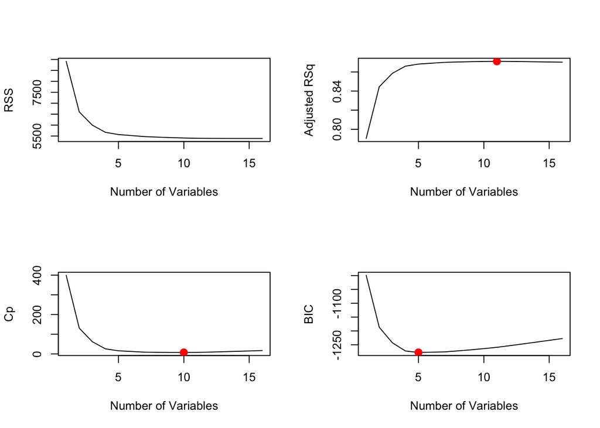

Now we’ll look at the selected variables for the best model with a given number of predictors.

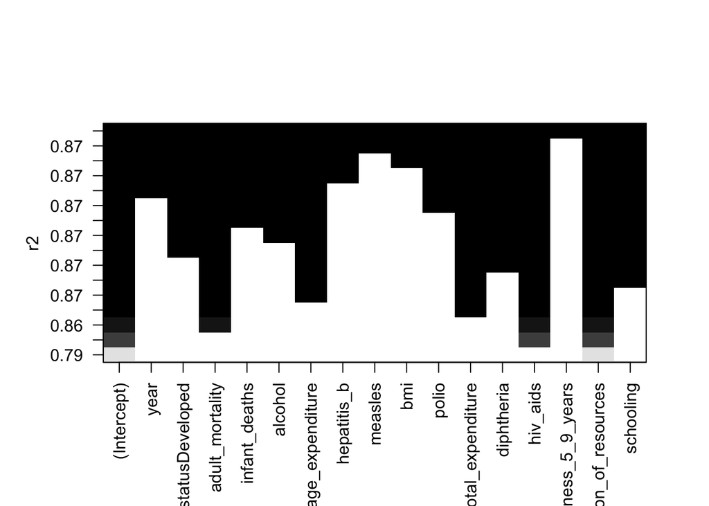

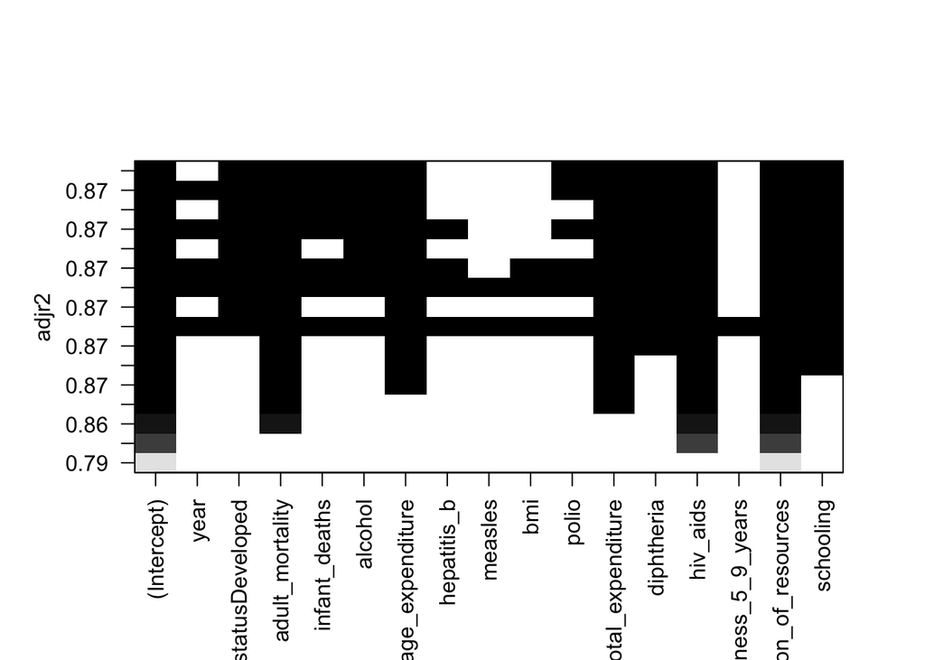

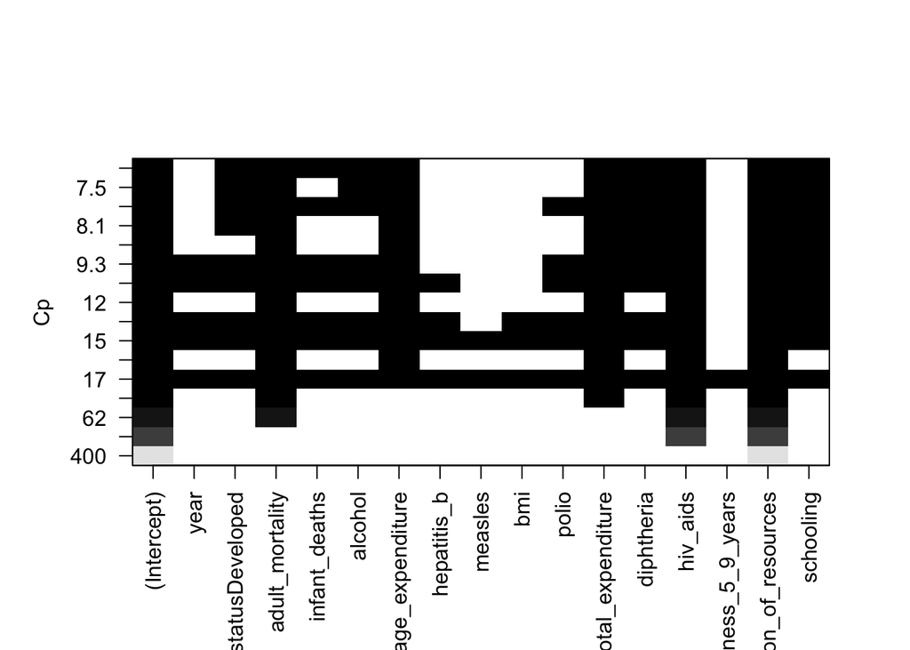

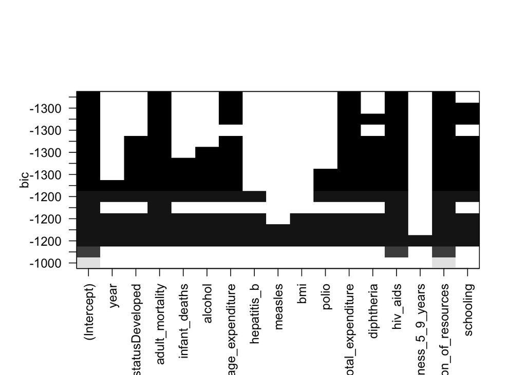

The model with the lowest BIC is the five-variable model that contains `adult_mortality`, `percentage_expenditure`, `total_expenditure`, `hiv_aids`, and `income_composition_of_resources`. We can use the `coef()` function to see the coefficient estimates associated with this model.

```
##                     (Intercept)                 adult_mortality
##                   48.0149724349                   -0.0127445024
##          percentage_expenditure               total_expenditure
##                    0.0002240715                    0.2721956765
##                        hiv_aids income_composition_of_resources
##                   -0.9311235477                   35.1964198338
```

### Run Forward and Backward Stepwise Selection

```
## Subset selection object
## Call: regsubsets.formula(life_expectancy ~ ., data = df_interp[, -1],
##     method = "forward")
## 16 Variables  (and intercept)
##                                 Forced in Forced out
## year                                FALSE      FALSE
## statusDeveloped                     FALSE      FALSE
## adult_mortality                     FALSE      FALSE
## infant_deaths                       FALSE      FALSE
## alcohol                             FALSE      FALSE
## percentage_expenditure              FALSE      FALSE
## hepatitis_b                         FALSE      FALSE
## measles                             FALSE      FALSE
## bmi                                 FALSE      FALSE
## polio                               FALSE      FALSE
## total_expenditure                   FALSE      FALSE
## diphtheria                          FALSE      FALSE
## hiv_aids                            FALSE      FALSE
## thinness_5_9_years                  FALSE      FALSE
## income_composition_of_resources     FALSE      FALSE
## schooling                           FALSE      FALSE
## 1 subsets of each size up to 8
## Selection Algorithm: forward
##          year statusDeveloped adult_mortality infant_deaths alcohol
## 1  ( 1 ) " "  " "             " "             " "           " "
## 2  ( 1 ) " "  " "             " "             " "           " "
## 3  ( 1 ) " "  " "             "*"             " "           " "
## 4  ( 1 ) " "  " "             "*"             " "           " "
## 5  ( 1 ) " "  " "             "*"             " "           " "
## 6  ( 1 ) " "  " "             "*"             " "           " "
## 7  ( 1 ) " "  " "             "*"             " "           " "
## 8  ( 1 ) " "  "*"             "*"             " "           " "
##          percentage_expenditure hepatitis_b measles bmi polio total_expenditure
## 1  ( 1 ) " "                    " "         " "     " " " "   " "
## 2  ( 1 ) " "                    " "         " "     " " " "   " "
## 3  ( 1 ) " "                    " "         " "     " " " "   " "
## 4  ( 1 ) " "                    " "         " "     " " " "   "*"
## 5  ( 1 ) "*"                    " "         " "     " " " "   "*"
## 6  ( 1 ) "*"                    " "         " "     " " " "   "*"
## 7  ( 1 ) "*"                    " "         " "     " " " "   "*"
## 8  ( 1 ) "*"                    " "         " "     " " " "   "*"
##          diphtheria hiv_aids thinness_5_9_years income_composition_of_resources
## 1  ( 1 ) " "        " "      " "                "*"
## 2  ( 1 ) " "        "*"      " "                "*"
## 3  ( 1 ) " "        "*"      " "                "*"
## 4  ( 1 ) " "        "*"      " "                "*"
## 5  ( 1 ) " "        "*"      " "                "*"
## 6  ( 1 ) " "        "*"      " "                "*"
## 7  ( 1 ) "*"        "*"      " "                "*"
## 8  ( 1 ) "*"        "*"      " "                "*"
##          schooling
## 1  ( 1 ) " "
## 2  ( 1 ) " "
## 3  ( 1 ) " "
## 4  ( 1 ) " "
## 5  ( 1 ) " "
## 6  ( 1 ) "*"
## 7  ( 1 ) "*"
## 8  ( 1 ) "*"
```

```
## Subset selection object
## Call: regsubsets.formula(life_expectancy ~ ., data = df_interp[, -1],
##     method = "backward")
## 16 Variables  (and intercept)
##                                 Forced in Forced out
## year                                FALSE      FALSE
## statusDeveloped                     FALSE      FALSE
## adult_mortality                     FALSE      FALSE
## infant_deaths                       FALSE      FALSE
## alcohol                             FALSE      FALSE
## percentage_expenditure              FALSE      FALSE
## hepatitis_b                         FALSE      FALSE
## measles                             FALSE      FALSE
## bmi                                 FALSE      FALSE
## polio                               FALSE      FALSE
## total_expenditure                   FALSE      FALSE
## diphtheria                          FALSE      FALSE
## hiv_aids                            FALSE      FALSE
## thinness_5_9_years                  FALSE      FALSE
## income_composition_of_resources     FALSE      FALSE
## schooling                           FALSE      FALSE
## 1 subsets of each size up to 8
## Selection Algorithm: backward
##          year statusDeveloped adult_mortality infant_deaths alcohol
## 1  ( 1 ) " "  " "             " "             " "           " "
## 2  ( 1 ) " "  " "             " "             " "           " "
## 3  ( 1 ) " "  " "             "*"             " "           " "
## 4  ( 1 ) " "  " "             "*"             " "           " "
## 5  ( 1 ) " "  " "             "*"             " "           " "
## 6  ( 1 ) " "  " "             "*"             " "           " "
## 7  ( 1 ) " "  " "             "*"             " "           " "
## 8  ( 1 ) " "  "*"             "*"             " "           " "
##          percentage_expenditure hepatitis_b measles bmi polio total_expenditure
## 1  ( 1 ) " "                    " "         " "     " " " "   " "
## 2  ( 1 ) " "                    " "         " "     " " " "   " "
## 3  ( 1 ) " "                    " "         " "     " " " "   " "
## 4  ( 1 ) " "                    " "         " "     " " " "   "*"
## 5  ( 1 ) "*"                    " "         " "     " " " "   "*"
## 6  ( 1 ) "*"                    " "         " "     " " " "   "*"
## 7  ( 1 ) "*"                    " "         " "     " " " "   "*"
## 8  ( 1 ) "*"                    " "         " "     " " " "   "*"
##          diphtheria hiv_aids thinness_5_9_years income_composition_of_resources
## 1  ( 1 ) " "        " "      " "                "*"
## 2  ( 1 ) " "        "*"      " "                "*"
## 3  ( 1 ) " "        "*"      " "                "*"
## 4  ( 1 ) " "        "*"      " "                "*"
## 5  ( 1 ) " "        "*"      " "                "*"
## 6  ( 1 ) " "        "*"      " "                "*"
## 7  ( 1 ) "*"        "*"      " "                "*"
## 8  ( 1 ) "*"        "*"      " "                "*"
##          schooling
## 1  ( 1 ) " "
## 2  ( 1 ) " "
## 3  ( 1 ) " "
## 4  ( 1 ) " "
## 5  ( 1 ) " "
## 6  ( 1 ) "*"
## 7  ( 1 ) "*"
## 8  ( 1 ) "*"
```

| variables | full | fwd | bwd |
| --- | --- | --- | --- |
| (Intercept) | 48.0149724349 | 48.0149724349 | 48.0149724349 |
| adult_mortality | -0.0127445024 | -0.0127445024 | -0.0127445024 |
| percentage_expenditure | 0.0002240715 | 0.0002240715 | 0.0002240715 |
| total_expenditure | 0.2721956765 | 0.2721956765 | 0.2721956765 |
| hiv_aids | -0.9311235477 | -0.9311235477 | -0.9311235477 |
| income_composition_of_resources | 35.1964198338 | 35.1964198338 | 35.1964198338 |

### Choose Using Validation Set

```r
# Find the best model
val_errors
```

```
##  [1] 12.323252  9.638071  9.016544  8.872022  9.084632  9.119632  9.364492
##  [8]  9.242942        NA        NA        NA        NA        NA        NA
## [15]        NA        NA        NA        NA
```

```r
coef(regfit_best, which.min(val_errors))
```

```
##                     (Intercept)                 adult_mortality
##                     47.62908661                     -0.01335286
##               total_expenditure                        hiv_aids
##                      0.35846536                     -1.07381687
## income_composition_of_resources
##                     35.78957983
```

```
##                     (Intercept)                 adult_mortality
##                     47.10581537                     -0.01274691
##               total_expenditure                        hiv_aids
##                      0.28913292                     -0.91092465
## income_composition_of_resources
##                     36.64852216
```

### Choose Using Cross-Validation

```
##         1         2         3         4         5         6         7         8
## 13.891261 10.350734  9.475315  9.057279  8.916776  9.072337  9.016923  8.959547
##         9        10        11        12        13        14        15        16
##  8.978886  8.954744  8.884795  8.891696  8.926716  8.935222  8.938186  8.938952
##        17        18
##        NA        NA
```

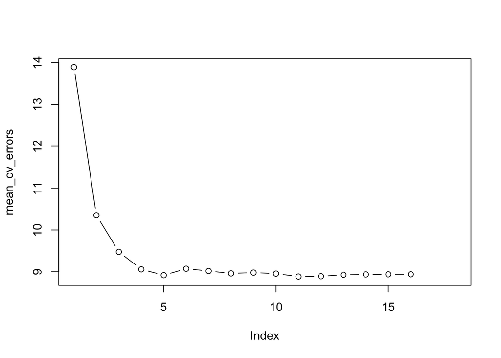

```
##                     (Intercept)                 adult_mortality
##                     47.10581537                     -0.01274691
##               total_expenditure                        hiv_aids
##                      0.28913292                     -0.91092465
## income_composition_of_resources
##                     36.64852216
```

### Build the Final Model

```
##
## Call:
## lm(formula = life_expectancy ~ adult_mortality + total_expenditure +
##     hiv_aids + income_composition_of_resources, data = df_interp)
##
## Residuals:
##      Min       1Q   Median       3Q      Max
## -11.6104  -1.7314  -0.1997   1.5992  11.1313
##
## Coefficients:
##                                  Estimate Std. Error t value Pr(>|t|)
## (Intercept)                     47.105815   0.861644  54.670  < 2e-16 ***
## adult_mortality                 -0.012747   0.001567  -8.132 2.18e-15 ***
## total_expenditure                0.289133   0.047527   6.084 2.02e-09 ***
## hiv_aids                        -0.910925   0.076112 -11.968  < 2e-16 ***
## income_composition_of_resources 36.648522   1.035874  35.379  < 2e-16 ***
## ---
## Signif. codes:  0 '***' 0.001 '**' 0.01 '*' 0.05 '.' 0.1 ' ' 1
##
## Residual standard error: 2.972 on 642 degrees of freedom
## Multiple R-squared:  0.8669, Adjusted R-squared:  0.8661
## F-statistic:  1045 on 4 and 642 DF,  p-value: < 2.2e-16
```

### Check Diagnostics

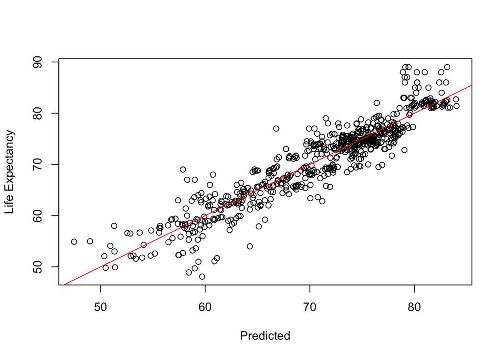

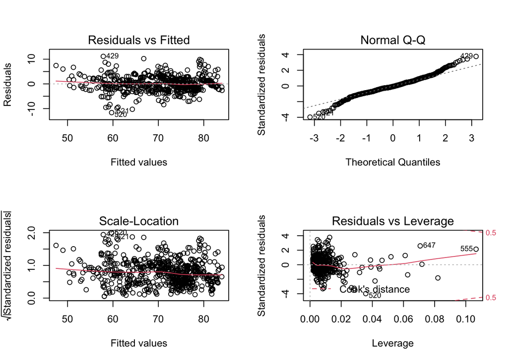

### Fit our Model to our Data Set

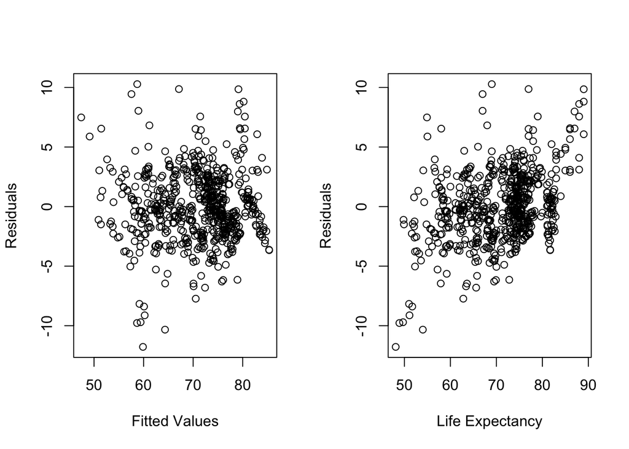

$Life~Expectancy = 47.106 - 0.013(Adult~Mortality) + 0.289(Total~Expenditure) - 0.911(HIV/AIDS) + 36.649(Income~Composition~of~Resources)$

## Objective 1

### Restatement of Problem and the Overall Approach to Solve It

### Model Selection

#### Type of Selection

- LASSO
- RIDGE
- ELASTIC NET
- Stepwise
- Forward
- Backward
- Manual / Intuition
- A mix of all of the above

#### Checking Assumptions

- Residual Plots
- Influential point analysis (Cook’s D and Leverage)

#### Compare Competing Models

Via: Training and test set split or CV Possible Metrics: ASE (Required), AIC, BIC, adj R2, are all welcome additions

#### Parameter Interpretation (Simple model only)

- Interpretation
- Confidence Intervals

## Appendix

### R Code

```r
knitr::opts_chunk$set(echo = TRUE)
library(tidyverse)
library(corrplot)
library(GGally)
library(gt)
library(hrbrthemes)
library(car)
library(leaps)
# Load data
df <- read_csv(here::here("data - raw", "Life Expectancy Data.csv"))

# Clean up column names
df_clean <- janitor::clean_names(df)

# Look at the data
glimpse(df_clean)
df_clean %>%
  ggplot(aes(life_expectancy)) +
  geom_histogram(fill = "steelblue", color = "black") +
  labs(title = "Histogram of Life Expectancy",
       x = "Age",
       y = "Count") +
  theme_ipsum()

df_clean %>%
  ggplot(aes(sample = life_expectancy)) +
  geom_qq(pch = 21, size = 3, na.rm = TRUE) +
  geom_qq_line(color = "indianred", na.rm = TRUE) +
  labs(title = "Quantile-Quantile Plot of Life Expectancy",
       x = "Theoretical",
       y = "Sample") +
  theme_ipsum()
# Convert country and status to factors
df_clean$country <- as_factor(df_clean$country)
df_clean$status  <- as_factor(df_clean$status)
ggcorr(
  df_clean,
  label = TRUE,
  label_alpha = TRUE,
  label_size = 3,
  layout.exp = 2,
  cex = 3.5,
  hjust = 1
)
df_clean %>%
  select(-c(under_five_deaths, gdp, thinness_1_19_years)) %>%
  ggcorr(
  label = TRUE,
  label_alpha = TRUE,
  label_size = 3,
  layout.exp = 2,
  cex = 3.5,
  hjust = 1
)
df_clean %>%
  select(-c(under_five_deaths, gdp, thinness_1_19_years, population)) %>%
  ggcorr(
  label = TRUE,
  label_alpha = TRUE,
  label_size = 3,
  layout.exp = 2,
  cex = 3.5,
  hjust = 1
)
df_clean <- df_clean %>%
  select(-c(under_five_deaths, gdp, thinness_1_19_years, population))
# Check for missing values
tibble(variable = names(colSums(is.na(df_clean))),
       missing = colSums(is.na(df_clean))) %>%
  gt()
# Drop all rows where life expectancy is NA
df_clean <- df_clean %>%
  filter(!is.na(life_expectancy))

# Recheck missing value counts
tibble(variable = names(colSums(is.na(df_clean))),
       missing = colSums(is.na(df_clean))) %>%
  gt()
# Drop remaining rows with NA's for the interpretable model
# Remove all rows with an NA
df_interp <- na.omit(df_clean)

# Final check of missing values
tibble(variable = names(colSums(is.na(df_interp))),
       missing = colSums(is.na(df_interp))) %>%
  gt()
df_interp %>% count(year)
df_interp <- df_interp %>% filter(year %in% 2011:2014)
# Set the maximum number of variables to consider in the model. Although the
# model can handle up to 20, the more we add, the less interpretable the final
# model will be.
consider <- 18

# Fit the model. We'll remove country, but keep it in the data set for
# interpretation.
regfit_full <-
  regsubsets(life_expectancy ~ .,
             df_interp[, -1],
             nvmax = consider)

# Examine the regression summary
reg_summary <- summary(regfit_full)
# Look at the names of reg_summary
names(reg_summary)

# What are the R-squared values?
reg_summary$rsq
par(mfrow = c(2, 2))
plot(reg_summary$rss,
     xlab = "Number of Variables",
     ylab = "RSS",
     type = "l")
plot(reg_summary$adjr2,
     xlab = "Number of Variables",
     ylab = "Adjusted RSq",
     type = "l")
which.max(reg_summary$adjr2)
points(
  11,
  reg_summary$adjr2[11],
  col = "red",
  cex = 2,
  pch = 20
)
plot(reg_summary$cp,
     xlab = "Number of Variables",
     ylab = "Cp",
     type = "l")
points(
  10,
  reg_summary$cp[which.min(reg_summary$cp)],
  col = "red",
  cex = 2,
  pch = 20
)
plot(reg_summary$bic,
     xlab = "Number of Variables",
     ylab = "BIC",
     type = "l")
points(
  5,
  reg_summary$bic[which.min(reg_summary$bic)],
  col = "red",
  cex = 2,
  pch = 20
)
plot(regfit_full, scale = "r2")
plot(regfit_full, scale = "adjr2")
plot(regfit_full, scale = "Cp")
plot(regfit_full, scale = "bic")
coef(regfit_full, 5)
# Forward
regfit_fwd <-
  regsubsets(life_expectancy ~ ., data = df_interp[, -1], method = "forward")
summary(regfit_fwd)

# Backward
regfit_bwd <-
  regsubsets(life_expectancy ~ ., data = df_interp[, -1], method = "backward")
summary(regfit_bwd)

# Compare coefficients
tibble(variables = names(coef(regfit_full, 5)),
       full = coef(regfit_full, 5),
       fwd = coef(regfit_fwd, 5),
       bwd = coef(regfit_bwd, 5)) %>%
  gt()
# Set seed
set.seed(1)

# Build test and training data sets, dropping country from regfit_best &
# test_mat because I was getting a warning that 1 linear dependencies found
train <- sample(c(TRUE, FALSE), nrow(df_interp), rep = TRUE)
test <- (!train)
regfit_best <- regsubsets(life_expectancy ~ ., data = df_interp[train, -1])
test_mat <- model.matrix(life_expectancy ~ ., data = df_interp[test, -1])

# Run a loop, and for each size `i`, extract the coefficients from `regfit_best`
# for the best model of that size, multiply them into the appropriate columns of
# the test model matric to form the predictions, and compute the test MSE.
val_errors <- rep(NA, consider)
for (i in 1:8) {
  coefi <- coef(regfit_best, id = i)
  pred <- test_mat[, names(coefi)] %*% coefi
  val_errors[i] <- mean((df_interp$life_expectancy[test] - pred)^2)
}
# Find the best model
val_errors
coef(regfit_best, which.min(val_errors))
# Write a prediction fuction
predict_regsubsets <- function(object, newdata, id, ...) {
  form <- as.formula(object$call[[2]])
  mat <- model.matrix(form, newdata)
  coefi <- coef(object, id = id)
  xvars <- names(coefi)
  mat[, xvars] %*% coefi
}

# Perform best subset selection on the full data set, and select the best model.
regfit_best <- regsubsets(life_expectancy ~ ., data = df_interp[,-1])
coef(regfit_best, which.min(val_errors))
k <- 10
set.seed(1)
folds <- sample(1:k, nrow(df_interp), replace = TRUE)
cv_errors <- matrix(NA, k, consider, dimnames = list(NULL, paste(1:consider)))

predict.regsubsets <- function(object, newdata, id, ...) {
  form <- as.formula(object$call[[2]])
  mat <- model.matrix(form, newdata)
  coefi <- coef(object, id = id)
  mat[, names(coefi)] %*% coefi
}

# Perform cross-validation
for (j in 1:k) {
  best_fit <-
    regsubsets(life_expectancy ~ ., data = df_interp[folds != j, -1], nvmax = consider)
  for (i in 1:16) {
    pred <- predict(best_fit, df_interp[folds == j, -1], id = i)
    cv_errors[j, i] <-
      mean((df_interp$life_expectancy[folds == j] - pred) ^ 2)
  }
}

# Use the apply function to average over the columns of the matrix in order to
# obtain a vector for which the jth element is the cross-validation error for
# the j-variable model.
mean_cv_errors <- apply(cv_errors, 2, mean)
mean_cv_errors
par(mfrow = c(1, 1))
plot(mean_cv_errors, type = "b")

# Perform best subset selection on the full data set in order to obtain the
# variables for the final model
reg_best <- regsubsets(life_expectancy ~ ., data = df_interp[, -1])
coef(reg_best, 4)  # the number sets the number of variables we want
# Build the final model using the best subset selection results
final_model <-
  lm(
    life_expectancy ~ adult_mortality +
      total_expenditure +
      hiv_aids +
      income_composition_of_resources,
    data = df_interp
)

# Final model summary
summary(final_model)
par(mfrow = c(1, 1))
plot(
  final_model$fitted.values,
  df_interp$life_expectancy,
  xlab = "Predicted",
  ylab = "Life Expectancy"
)
lines(c(0, 90), c(0, 90), col = "red")

par(mfrow=c(2,2))
plot(final_model)
par(mfrow = c(1, 2))
test.model <- lm(life_expectancy ~ ., df_interp[, -1])
plot(test.model$fitted.values,
     test.model$residuals,
     xlab = "Fitted Values",
     ylab = "Residuals")
plot(df_interp$life_expectancy,
     test.model$residuals,
     xlab = "Life Expectancy",
     ylab = "Residuals")
```